# natural processing language

- pacotes no R: gutenbergr,wordcloud,stringr,SnowballC,widyr,janeaustenr,stopwords
- Token: menor unidade do texto que faz sentido
- token n-grama: é um token com palavras agrupadas na sequência
- stop words: palavras que consideraremos sem sentido e tiraremos da análise
- stemming: reduzir as palavras para os radicais
- lematização: reduzir as palavras com mesmo significado/raiz (agrupar diferentes formas da mesma palavra)

pacotes:

```r
library("tidyverse")
library("tidytext")
```

Texto de Edgar Allan Poe - the black cat

```r
text <- c("From my infancy I was noted for the docility and humanity of my disposition.",
      "My tenderness of heart was even so conspicuous as to make me the jest of my companions.",
      "There is something in the unselfish and self-sacrificing love of a brute, which goes directly to the heart of him who has had frequent occasion to test the paltry friendship and gossamer fidelity of mere Man.")

text_df = tibble(line = 1:3, text = text)
```

Criação do dataframe com os tokens, tudo foi passado para minusculo e a pontuação foi removida:

```r
df = text_df |> unnest_tokens(word, text)
```

stop_words são palavras do pacotes tidytext. Retornando o que tem em df mas não tem em stop_words:

```r
df_sem_stop_words <- df |> anti_join(stop_words)
```

Palavras mais comuns

```r
df_sem_stop_words |>  count(word, sort = TRUE)
```

| word | n |
| --- | --- |
| heart | 2 |
| brute | 1 |
| companions | 1 |
| conspicuous | 1 |
| directly | 1 |
| disposition | 1 |
| docility | 1 |
| fidelity | 1 |
| frequent | 1 |
| friendship | 1 |

[output cut: 13 more lines]

Gráfico:

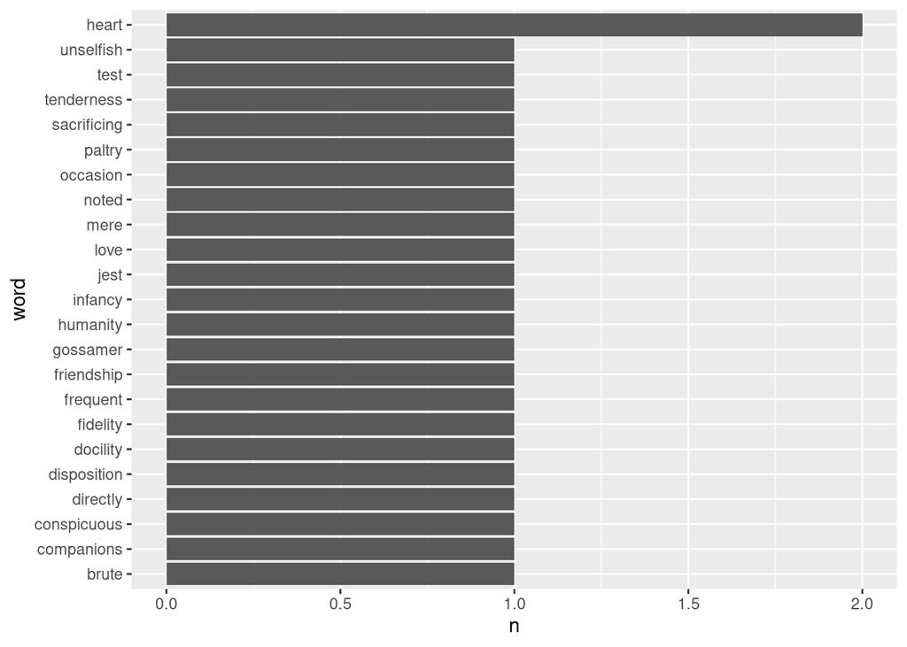

```r
df_sem_stop_words |>
  count(word, sort = TRUE) |>
  mutate(word = reorder(word, n)) |>
  ggplot(aes(n, word)) +
  geom_col()
```

metadados de livros diversos que podemos baixar para análises:

```r
library("gutenbergr")
textos <- gutenberg_metadata
textos[16:17,]
```

| gutenberg_id | title | author | gutenberg_author_id | language | gutenberg_bookshelf | rights | has_text |
| --- | --- | --- | --- | --- | --- | --- | --- |
| 15 | Moby Dick | Melville, Herman | 9 | en | Best Books Ever Listings/Adventure | Public domain in the USA. | TRUE |
| 16 | Peter Pan | Barrie, J. M. (James Matthew) | 10 | en | Movie Books/Children's Literature | Copyrighted. Read the copyright notice inside this book for details. | TRUE |

Vamos usar Peter Pan e Moby Dick:

```r
livros <- gutenberg_download(c(15,16))
```

Exemplo de como retirar números:

```r
nums = livros |> filter(str_detect(text, "^[0-9]")) |> select(text)
livros = livros |>  anti_join(nums, by = "text")
```

Gerando tokens e removendo stopwords:

```r
livros = livros |>  unnest_tokens(word, text)
livros = livros |>  anti_join(stop_words)
```

Moby Dick:

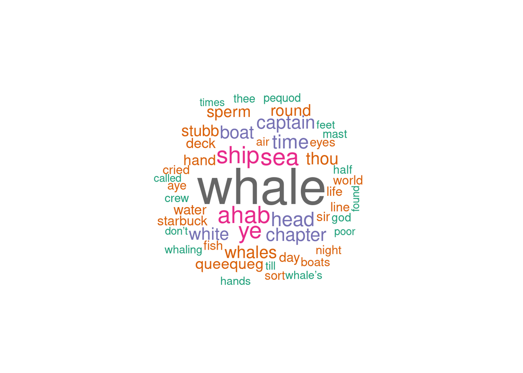

```r
library("wordcloud")
library("stringr")
library("SnowballC")

moby <- livros |> filter(gutenberg_id == 15) |> count(word, sort = TRUE)
pal <- brewer.pal(8,"Dark2") # paleta de cores
moby |> with(wordcloud(word, n, random.order = FALSE, max.words = 50, colors=pal))
```

Word cloud com 50 palavras do Peter Pan:

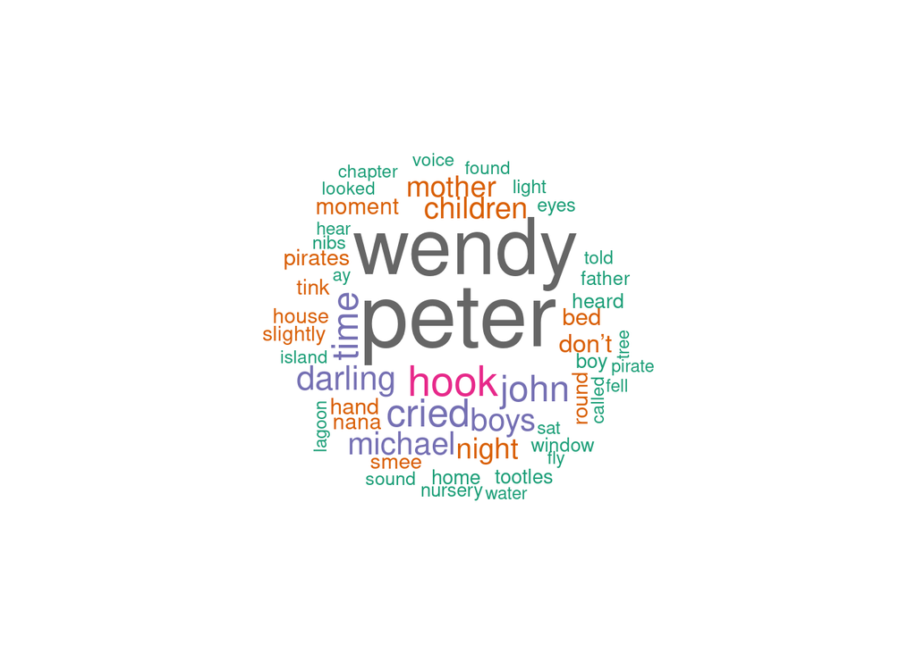

```r
peter = livros |> filter(gutenberg_id == 16) |> count(word, sort = TRUE)
pal = brewer.pal(8,"Dark2")
peter |> with(wordcloud(word, n, random.order = FALSE, max.words = 50, colors=pal))
```

Aplicando a stemming (extração dos radicais) nas palavras:

```r
peter_stem = peter |>  mutate(stem = wordStem(word))
peter_stem_count = livros |> filter(gutenberg_id == 16) |> mutate(stem = wordStem(word)) |> count(stem, sort = TRUE)
```

Baixando livro e português:

```r
gutenberg_pt_br = textos[textos$language == 'pt',c('gutenberg_id','title','author')]
head(gutenberg_pt_br)
```

| gutenberg_id | title | author |
| --- | --- | --- |
| 2837 | Lendas do sul | Lopes Neto, J. Simões (João Simões) |
| 3333 | Os Lusíadas | Camões, Luís de |
| 7384 | Carta da Companhia de Jesus para o seráfico São Francisco | Anchieta, José de |
| 8698 | O Livro de Cesario Verde | Verde, Cesário |
| 9654 | Lendas e Narrativas (Tomo I) | Herculano, Alexandre |
| 11299 | O cancioneiro portuguez da Vaticana | Braga, Teófilo |

```r
gutenberg_pt_br[gutenberg_pt_br$gutenberg_id==3333,]
```

| gutenberg_id | title | author |
| --- | --- | --- |
| 3333 | Os Lusíadas | Camões, Luís de |

Os Lusíadas:

```r
livro <- gutenberg_download(c(3333))
```

Corrigindo encoding:

```r
Encoding(livro$text) = "latin1"
```

Retirar os acentos:

```r
library(stringi)
livro$text = stri_trans_general(livro$text, "Latin-ASCII")
```

Tokens:

```r
livro = livro |> unnest_tokens(word, text)
```

stop words em português

```r
stopwords_pt = get_stopwords(language = 'pt')
```

Remove stopwords:

```r
livro = livro |> anti_join(stopwords_pt)
```

Word cloud - teste word e stem

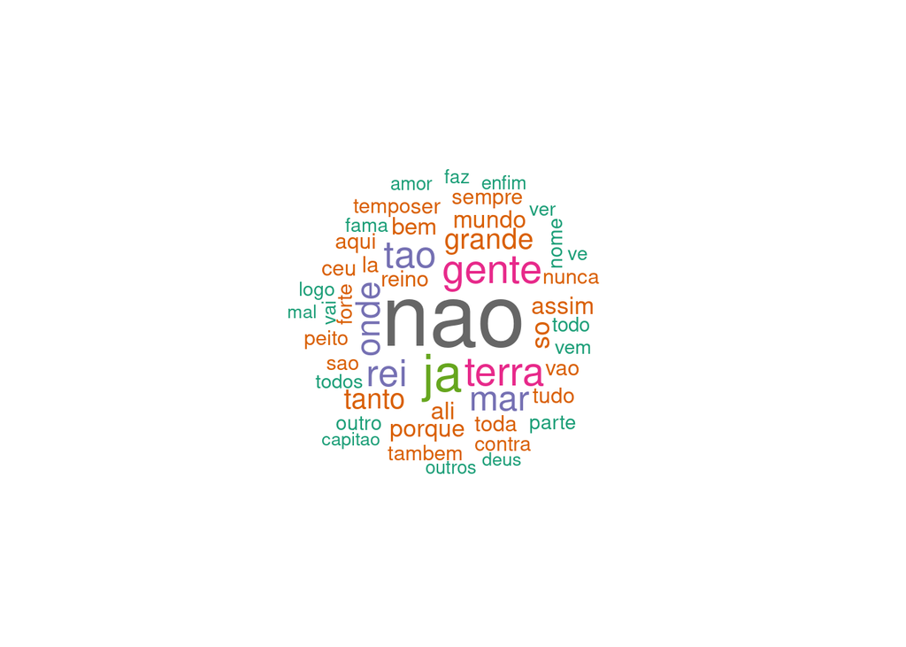

```r
livro_cont = livro |> select(word) |> count(word, sort = TRUE)
pal = brewer.pal(8,"Dark2")
livro_cont |> with(wordcloud(word, n, random.order = FALSE, max.words = 50, colors=pal))
```

Exemplo de n gramas de 2 (bigrama):

```r
livro <- gutenberg_download(c(3333))
Encoding(livro$text) = "latin1"
livro$text = stri_trans_general(livro$text, "Latin-ASCII")
livro = livro |> unnest_tokens(word, text, token = "ngrams", n = 2)
livro = livro |> anti_join(stopwords_pt)
bigrama_contagem = livro |> count(word, sort = TRUE)
```

Correlação de Pearson entre palavras - widyr:

```r
library("widyr")
library("janeaustenr")

austen_section_words <- austen_books() |>
  filter(book == "Pride & Prejudice") |>
  mutate(section = row_number() %/% 10) |>
  filter(section > 0) |>
  unnest_tokens(word, text) |>
  filter(!word %in% stop_words$word)
```

Pares de palavras:

```r
word_pairs <- austen_section_words |> pairwise_count(word, section, sort = TRUE)
```

Correlações:

```r
word_cors <- austen_section_words %>%
  group_by(word) %>%
  filter(n() >= 20) %>%
  pairwise_cor(word, section, sort = TRUE)
word_cors
```

| item1 | item2 | correlation |
| --- | --- | --- |
| bourgh | de | 0.95085013 |
| de | bourgh | 0.95085013 |
| pounds | thousand | 0.70058081 |
| thousand | pounds | 0.70058081 |
| william | sir | 0.66447194 |
| sir | william | 0.66447194 |
| catherine | lady | 0.66330480 |
| lady | catherine | 0.66330480 |
| forster | colonel | 0.62209495 |
| colonel | forster | 0.62209495 |

[output cut: 9990 more lines]